# Homework4Solutions

Noah Moyer

2023-02-25

## Getting set up

```r
#load required packages
library(tidymodels)
library(ISLR)
library(ISLR2)
library(tidyverse)
library(ggthemes)
library(here)
library(themis)
tidymodels_prefer()

#read in the datasets
abalone <- read.csv(here("Homework", "Homework4", "data", "abalone.csv"))
titanic <- read.csv(here("Homework", "Homework4", "data", "titanic.csv"))

#change variabels to factor
titanic$survived <- as.factor(titanic$survived)
titanic$pclass <- as.factor(titanic$pclass)

#generate age variable
abalone$age <- abalone$rings + 1.5

#getting familiar with the datasets
str(abalone)
```

```
## 'data.frame':    4177 obs. of  10 variables:
##  $ type          : chr  "M" "M" "F" "M" ...
##  $ longest_shell : num  0.455 0.35 0.53 0.44 0.33 0.425 0.53 0.545 0.475 0.55 ...
##  $ diameter      : num  0.365 0.265 0.42 0.365 0.255 0.3 0.415 0.425 0.37 0.44 ...
##  $ height        : num  0.095 0.09 0.135 0.125 0.08 0.095 0.15 0.125 0.125 0.15 ...
##  $ whole_weight  : num  0.514 0.226 0.677 0.516 0.205 ...
##  $ shucked_weight: num  0.2245 0.0995 0.2565 0.2155 0.0895 ...
##  $ viscera_weight: num  0.101 0.0485 0.1415 0.114 0.0395 ...
##  $ shell_weight  : num  0.15 0.07 0.21 0.155 0.055 0.12 0.33 0.26 0.165 0.32 ...
##  $ rings         : int  15 7 9 10 7 8 20 16 9 19 ...
##  $ age           : num  16.5 8.5 10.5 11.5 8.5 9.5 21.5 17.5 10.5 20.5 ...
```

```r
str(titanic)
```

```
## 'data.frame':    891 obs. of  12 variables:
##  $ passenger_id: int  1 2 3 4 5 6 7 8 9 10 ...
##  $ survived    : Factor w/ 2 levels "No","Yes": 1 2 2 2 1 1 1 1 2 2 ...
##  $ pclass      : Factor w/ 3 levels "1","2","3": 3 1 3 1 3 3 1 3 3 2 ...
##  $ name        : chr  "Braund, Mr. Owen Harris" "Cumings, Mrs. John Bradley (Florence Briggs Thayer)" "Heikkinen, Miss. Laina" "Futrelle, Mrs. Jacques Heath (Lily May Peel)" ...
##  $ sex         : chr  "male" "female" "female" "female" ...
##  $ age         : num  22 38 26 35 35 NA 54 2 27 14 ...
##  $ sib_sp      : int  1 1 0 1 0 0 0 3 0 1 ...
##  $ parch       : int  0 0 0 0 0 0 0 1 2 0 ...
##  $ ticket      : chr  "A/5 21171" "PC 17599" "STON/O2. 3101282" "113803" ...
##  $ fare        : num  7.25 71.28 7.92 53.1 8.05 ...
##  $ cabin       : chr  NA "C85" NA "C123" ...
##  $ embarked    : chr  "S" "C" "S" "S" ...
```

## Section 1: Regression (abalone age)

### Question 1

```r
set.seed(6920)

#split data
abaloneSplit <- initial_split(abalone, prop=0.75, strata=age)

#training set
abaloneTraining <- training(abaloneSplit)

#testing set
abaloneTesting <- testing(abaloneSplit)

#create a 5-fold cross-validation set
abaloneFolds <- vfold_cv(abaloneTraining, v=5)

#check that this worked
abaloneFolds[[1]] %>%
  head()
```

```
## [[1]]
## <Analysis/Assess/Total>
## <2504/627/3131>
##
## [[2]]
## <Analysis/Assess/Total>
## <2505/626/3131>
##
## [[3]]
## <Analysis/Assess/Total>
## <2505/626/3131>
##
## [[4]]
## <Analysis/Assess/Total>
## <2505/626/3131>
##
## [[5]]
## <Analysis/Assess/Total>
## <2505/626/3131>
```

```r
#create a recipe with all predictors
abaloneRecipe <- recipe(age~., data=abaloneTraining)

#remove rings predictor and add some interactiont erms
abaloneRecipeFinal <- abaloneRecipe %>%
  step_dummy(all_nominal_predictors()) %>%
  step_interact(terms=~shucked_weight:starts_with("type")+longest_shell:diameter+shucked_weight:shell_weight)  %>%
  step_rm(rings) %>%
  step_center() %>%
  step_scale()
```

### Question 2

K-fold cross validation is a way of splitting the training dataset up in order to test various models before we select a final model to be applied to the testing dataset. K-fold works by dividing the training dataset up k different ways. Each k is now an assessment dataset. For each assessment dataset, the rest of the training dataset (called the analysis dataset) is fitted to each model and then tested on the assessment dataset. When we finish k-fold cross validation we have a series of testing metrics that tell us how well each model performed on a wide variety of assessment datasets. If we just compared our model results on the training dataset we may overfit some of the models since we aren’t testing the models on independent data. This may lead to bias. If we split our training set into two and used one of the two splits to evaluate our models, this would be known as validation set approach.

### Question 3

```r
#setting up the model for k-nearest neighbors
knn_mod_tune <- nearest_neighbor(neighbors=tune()) %>%
  set_mode("regression") %>%
  set_engine("kknn")

#setting up the model for the linear regression
lin_regress <- linear_reg() %>%
  set_mode("regression") %>%
  set_engine("lm")

#setting up the model for elastic net linear regression
elastic_net_linear <- linear_reg(mixture=tune(),
                                 penalty=tune()) %>%
  set_mode("regression") %>%
  set_engine("glmnet")

#setting up workflow for knn
knn_workflow <- workflow() %>%
  add_model(knn_mod_tune) %>%
  add_recipe(abaloneRecipeFinal)

#setting up workflow for linear regression
lin_regress_workflow <- workflow() %>%
  add_model(linear_reg()) %>%
  add_recipe(abaloneRecipeFinal)

#setting up workflow for elastic net linear regression
elastic_net_linear_workflow <- workflow() %>%
  add_model(elastic_net_linear) %>%
  add_recipe(abaloneRecipeFinal)

#set up the tuning for KNN
knn_grid <- grid_regular(neighbors(range=c(1,10)), levels=10)

#set up tuning for elastic net linear regression
ENL_grid <- grid_regular(penalty(), mixture(range=c(0,1)), levels=10)

#check the compisition of each grids
knn_grid
```

```
## # A tibble: 10 × 1
##    neighbors
##        <int>
##  1         1
##  2         2
##  3         3
##  4         4
##  5         5
##  6         6
##  7         7
##  8         8
##  9         9
## 10        10
```

```r
ENL_grid
```

```
## # A tibble: 100 × 2
##          penalty mixture
##            <dbl>   <dbl>
##  1 0.0000000001        0
##  2 0.00000000129       0
##  3 0.0000000167        0
##  4 0.000000215         0
##  5 0.00000278          0
##  6 0.0000359           0
##  7 0.000464            0
##  8 0.00599             0
##  9 0.0774              0
## 10 1                   0
## # … with 90 more rows
```

Since we are doing k-folds with 5 folds, each specific model will be tested 5 times. We set up 10 models for knn and 100 models for elastic net linear regression. That, plus the one model of just the plain linear regression means that we have 111 models to test. Thus, $111*5=555$ so we have 555 models to fit and test.

### Question 4

```r
#fit the KNN model
knn_fit <- tune_grid(
  object=knn_workflow,
  resamples=abaloneFolds,
  grid=knn_grid,
  control=control_grid(verbose=TRUE)
)
```

[output not shown]

[output not shown]

[output not shown]

[output not shown]

[output not shown]

[output not shown]

[output not shown]

[output not shown]

[output not shown]

[output not shown]

[output not shown]

[output not shown]

[output not shown]

[output not shown]

[output not shown]

[output not shown]

[output not shown]

[output not shown]

[output not shown]

[output not shown]

[output not shown]

[output not shown]

[output not shown]

[output not shown]

[output not shown]

```r
#fit the linear model
lin_fit <- fit_resamples(
  object=lin_regress_workflow,
  resamples=abaloneFolds
)

#fit the ENL model
ENL_fit <- tune_grid(
  object=elastic_net_linear_workflow,
  resamples=abaloneFolds,
  grid=ENL_grid,
  control=control_grid(verbose=TRUE)
)
```

[output not shown]

[output not shown]

[output not shown]

[output not shown]

[output not shown]

[output not shown]

[output not shown]

[output not shown]

[output not shown]

[output not shown]

[output not shown]

[output not shown]

[output not shown]

[output not shown]

[output not shown]

[output not shown]

[output not shown]

[output not shown]

[output not shown]

[output not shown]

[output not shown]

[output not shown]

[output not shown]

[output not shown]

[output not shown]

[output not shown]

[output not shown]

[output not shown]

[output not shown]

[output not shown]

[output not shown]

[output not shown]

[output not shown]

[output not shown]

[output not shown]

[output not shown]

[output not shown]

[output not shown]

[output not shown]

[output not shown]

[output not shown]

[output not shown]

[output not shown]

[output not shown]

[output not shown]

[output not shown]

[output not shown]

[output not shown]

[output not shown]

[output not shown]

[output not shown]

[output not shown]

[output not shown]

[output not shown]

[output not shown]

[output not shown]

[output not shown]

[output not shown]

[output not shown]

[output not shown]

[output not shown]

[output not shown]

[output not shown]

[output not shown]

[output not shown]

[output not shown]

[output not shown]

[output not shown]

[output not shown]

[output not shown]

[output not shown]

[output not shown]

[output not shown]

[output not shown]

[output not shown]

[output not shown]

[output not shown]

[output not shown]

[output not shown]

[output not shown]

[output not shown]

[output not shown]

[output not shown]

[output not shown]

[output not shown]

[output not shown]

[output not shown]

[output not shown]

[output not shown]

[output not shown]

[output not shown]

[output not shown]

[output not shown]

[output not shown]

[output not shown]

[output not shown]

[output not shown]

[output not shown]

[output not shown]

[output not shown]

[output not shown]

[output not shown]

[output not shown]

[output not shown]

[output not shown]

[output not shown]

[output not shown]

[output not shown]

[output not shown]

[output not shown]

[output not shown]

[output not shown]

[output not shown]

[output not shown]

[output not shown]

[output not shown]

[output not shown]

[output not shown]

[output not shown]

[output not shown]

[output not shown]

[output not shown]

[output not shown]

[output not shown]

[output not shown]

[output not shown]

[output not shown]

[output not shown]

[output not shown]

[output not shown]

[output not shown]

[output not shown]

[output not shown]

[output not shown]

[output not shown]

[output not shown]

[output not shown]

[output not shown]

[output not shown]

[output not shown]

[output not shown]

[output not shown]

[output not shown]

[output not shown]

[output not shown]

[output not shown]

[output not shown]

[output not shown]

[output not shown]

[output not shown]

[output not shown]

[output not shown]

[output not shown]

[output not shown]

[output not shown]

[output not shown]

[output not shown]

[output not shown]

[output not shown]

[output not shown]

### Question 5

```r
#see how the KNN model did
knn_model <- subset(collect_metrics(knn_fit), .metric=="rmse")
knn_model[order(knn_model$mean),]
```

```
## # A tibble: 10 × 7
##    neighbors .metric .estimator  mean     n std_err .config
##        <int> <chr>   <chr>      <dbl> <int>   <dbl> <chr>
##  1        10 rmse    standard    2.28     5  0.0335 Preprocessor1_Model10
##  2         9 rmse    standard    2.29     5  0.0340 Preprocessor1_Model09
##  3         8 rmse    standard    2.31     5  0.0344 Preprocessor1_Model08
##  4         7 rmse    standard    2.33     5  0.0348 Preprocessor1_Model07
##  5         6 rmse    standard    2.36     5  0.0347 Preprocessor1_Model06
##  6         5 rmse    standard    2.40     5  0.0345 Preprocessor1_Model05
##  7         4 rmse    standard    2.46     5  0.0344 Preprocessor1_Model04
##  8         3 rmse    standard    2.55     5  0.0351 Preprocessor1_Model03
##  9         2 rmse    standard    2.70     5  0.0388 Preprocessor1_Model02
## 10         1 rmse    standard    2.90     5  0.0442 Preprocessor1_Model01
```

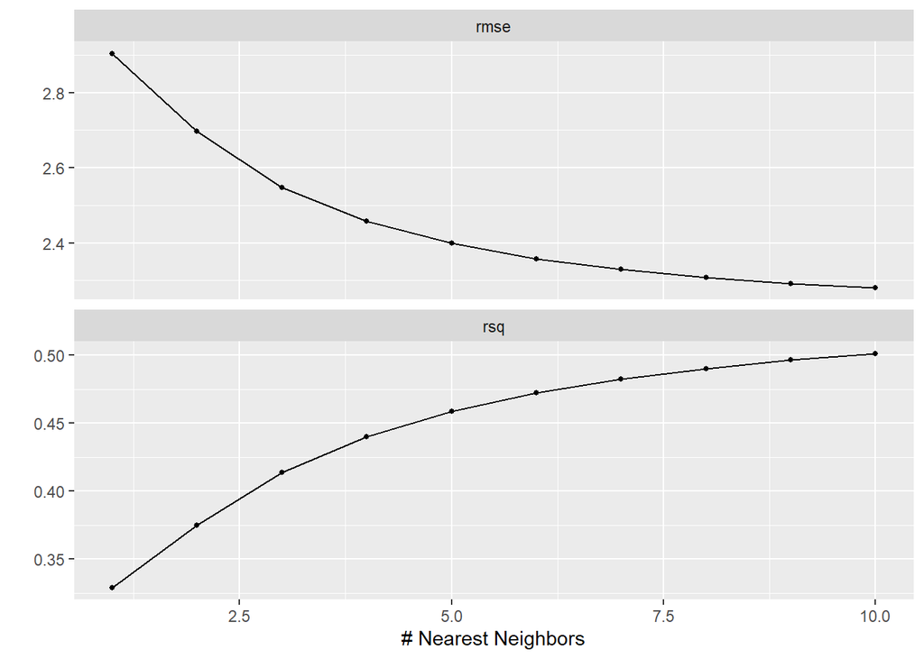

```r
autoplot(knn_fit)
```

```r
#see how the linear model did
subset(collect_metrics(lin_fit), .metric=="rmse")
```

```
## # A tibble: 1 × 6
##   .metric .estimator  mean     n std_err .config
##   <chr>   <chr>      <dbl> <int>   <dbl> <chr>
## 1 rmse    standard    2.21     5  0.0459 Preprocessor1_Model1
```

```r
#see how the ENL model did
ENL_mod <- subset(collect_metrics(ENL_fit), .metric=="rmse")
ENL_mod[order(ENL_mod$mean),]
```

```
## # A tibble: 100 × 8
##          penalty mixture .metric .estimator  mean     n std_err .config
##            <dbl>   <dbl> <chr>   <chr>      <dbl> <int>   <dbl> <chr>
##  1 0.0000000001    0.222 rmse    standard    2.21     5  0.0449 Preprocessor1_M…
##  2 0.00000000129   0.222 rmse    standard    2.21     5  0.0449 Preprocessor1_M…
##  3 0.0000000167    0.222 rmse    standard    2.21     5  0.0449 Preprocessor1_M…
##  4 0.000000215     0.222 rmse    standard    2.21     5  0.0449 Preprocessor1_M…
##  5 0.00000278      0.222 rmse    standard    2.21     5  0.0449 Preprocessor1_M…
##  6 0.0000359       0.222 rmse    standard    2.21     5  0.0449 Preprocessor1_M…
##  7 0.000464        0.222 rmse    standard    2.21     5  0.0449 Preprocessor1_M…
##  8 0.0000000001    0.889 rmse    standard    2.21     5  0.0452 Preprocessor1_M…
##  9 0.00000000129   0.889 rmse    standard    2.21     5  0.0452 Preprocessor1_M…
## 10 0.0000000167    0.889 rmse    standard    2.21     5  0.0452 Preprocessor1_M…
## # … with 90 more rows
```

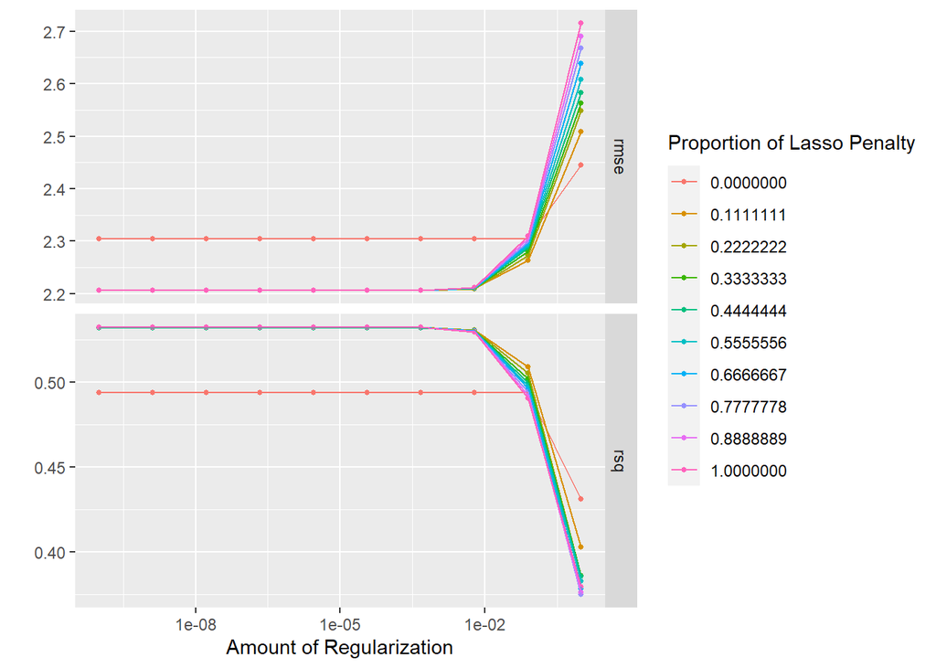

```r
autoplot(ENL_fit)
```

Out of the KNN model, the model with 10 nearest neighbors performed the best with an RMSE of 2.279997. The linear model had an RMSE of 2.206268, outperforming the best KNN model. The best elastic net linear regression model had an RMSE 2.206262. There were a series of models with this RMSE and they all had a mixture of 2/9 Lasso Regression. Their penalty term was 4.64e-04 and lower. While the elastic net linear regression model has a lower RMSE than the linear model, the difference is so small that I believe the more simple model is better suited. Thus, the linear model was the model that performed the best.

### Question 6

```r
#fit entire training set to the linear model
final_fit <- fit(lin_regress_workflow, abaloneTraining)

#find rmse
augment(final_fit, new_data=abaloneTesting) %>%
  rmse(truth=age, estimate=.pred)
```

```
## # A tibble: 1 × 3
##   .metric .estimator .estimate
##   <chr>   <chr>          <dbl>
## 1 rmse    standard        2.12
```

## Section 2: Classification (Titanic Survival)

### Question 7

```r
set.seed(2523)

#split up titanic
titanic_split <- initial_split(titanic, strata=survived, prop=0.7)
titanic_train <- training(titanic_split)
titanic_test <- testing(titanic_split)

#create a 5-fold CV set
titanic_folds <- vfold_cv(titanic_train, v=5)
```

### Question 8

```r
#create the recipe
titanic_recipe <- recipe(survived ~ pclass + sex + age + sib_sp + parch + fare, titanic_train) %>%
  step_impute_linear(age, impute_with = imp_vars(pclass, sex, sib_sp, parch, fare)) %>%
  step_dummy(all_nominal_predictors()) %>%
  step_interact(~starts_with("sex"):age + age:fare) %>%
  step_upsample(survived, over_ratio=1)
```

### Question 9

```r
#setting up the model for KNN
knn_mod_class <- nearest_neighbor(neighbors=tune()) %>%
  set_mode("classification") %>%
  set_engine("kknn")

#setting up the model for logistic regression
log_reg_class <- logistic_reg() %>%
  set_mode("classification") %>%
  set_engine("glm")

#setting up the model for elastic net logistic regression
ENLog_class <- logistic_reg(mixture=tune(),
                            penalty=tune()) %>%
  set_mode("classification") %>%
  set_engine("glmnet")

#setting up workflow for KNN
knn_work_titan <- workflow() %>%
  add_model(knn_mod_class) %>%
  add_recipe(titanic_recipe)

#setting up workflow for logistic regression
log_work_titan <- workflow() %>%
  add_model(log_reg_class) %>%
  add_recipe(titanic_recipe)

#setting up workflow for ENLog
ENLog_work_titan <- workflow() %>%
  add_model(ENLog_class) %>%
  add_recipe(titanic_recipe)

#will use same grids as before
knn_grid
```

```
## # A tibble: 10 × 1
##    neighbors
##        <int>
##  1         1
##  2         2
##  3         3
##  4         4
##  5         5
##  6         6
##  7         7
##  8         8
##  9         9
## 10        10
```

```r
ENL_grid
```

```
## # A tibble: 100 × 2
##          penalty mixture
##            <dbl>   <dbl>
##  1 0.0000000001        0
##  2 0.00000000129       0
##  3 0.0000000167        0
##  4 0.000000215         0
##  5 0.00000278          0
##  6 0.0000359           0
##  7 0.000464            0
##  8 0.00599             0
##  9 0.0774              0
## 10 1                   0
## # … with 90 more rows
```

### Question 10

```r
#fit the KNN model
knn_fit_titan <- tune_grid(
  object=knn_work_titan,
  resamples=titanic_folds,
  grid=knn_grid,
  control=control_grid(verbose=TRUE)
)
```

[output not shown]

[output not shown]

[output not shown]

[output not shown]

[output not shown]

[output not shown]

[output not shown]

[output not shown]

[output not shown]

[output not shown]

[output not shown]

[output not shown]

[output not shown]

[output not shown]

[output not shown]

[output not shown]

[output not shown]

[output not shown]

[output not shown]

[output not shown]

[output not shown]

[output not shown]

[output not shown]

[output not shown]

[output not shown]

```r
#fit the log model
log_fit_titan <- fit_resamples(
  object=log_work_titan,
  resamples=titanic_folds
)

#fit the ENLog model
ENLog_fit_titan <- tune_grid(
  object=ENLog_work_titan,
  resamples=titanic_folds,
  grid=ENL_grid,
  control=control_grid(verbose=TRUE)
)
```

[output not shown]

[output not shown]

[output not shown]

[output not shown]

[output not shown]

[output not shown]

[output not shown]

[output not shown]

[output not shown]

[output not shown]

[output not shown]

[output not shown]

[output not shown]

[output not shown]

[output not shown]

[output not shown]

[output not shown]

[output not shown]

[output not shown]

[output not shown]

[output not shown]

[output not shown]

[output not shown]

[output not shown]

[output not shown]

[output not shown]

[output not shown]

[output not shown]

[output not shown]

[output not shown]

[output not shown]

[output not shown]

[output not shown]

[output not shown]

[output not shown]

[output not shown]

[output not shown]

[output not shown]

[output not shown]

[output not shown]

[output not shown]

[output not shown]

[output not shown]

[output not shown]

[output not shown]

[output not shown]

[output not shown]

[output not shown]

[output not shown]

[output not shown]

[output not shown]

[output not shown]

[output not shown]

[output not shown]

[output not shown]

[output not shown]

[output not shown]

[output not shown]

[output not shown]

[output not shown]

[output not shown]

[output not shown]

[output not shown]

[output not shown]

[output not shown]

[output not shown]

[output not shown]

[output not shown]

[output not shown]

[output not shown]

[output not shown]

[output not shown]

[output not shown]

[output not shown]

[output not shown]

[output not shown]

[output not shown]

[output not shown]

[output not shown]

[output not shown]

[output not shown]

[output not shown]

[output not shown]

[output not shown]

[output not shown]

[output not shown]

[output not shown]

[output not shown]

[output not shown]

[output not shown]

[output not shown]

[output not shown]

[output not shown]

[output not shown]

[output not shown]

[output not shown]

[output not shown]

[output not shown]

[output not shown]

[output not shown]

[output not shown]

[output not shown]

[output not shown]

[output not shown]

[output not shown]

[output not shown]

[output not shown]

[output not shown]

[output not shown]

[output not shown]

[output not shown]

[output not shown]

[output not shown]

[output not shown]

[output not shown]

[output not shown]

[output not shown]

[output not shown]

[output not shown]

[output not shown]

[output not shown]

[output not shown]

[output not shown]

[output not shown]

[output not shown]

[output not shown]

[output not shown]

[output not shown]

[output not shown]

[output not shown]

[output not shown]

[output not shown]

[output not shown]

[output not shown]

[output not shown]

[output not shown]

[output not shown]

[output not shown]

[output not shown]

[output not shown]

[output not shown]

[output not shown]

[output not shown]

[output not shown]

[output not shown]

[output not shown]

[output not shown]

[output not shown]

[output not shown]

[output not shown]

[output not shown]

[output not shown]

[output not shown]

[output not shown]

[output not shown]

[output not shown]

[output not shown]

[output not shown]

[output not shown]

[output not shown]

### Question 11

```r
#see how the KNN model did
knn_model_titan <- subset(collect_metrics(knn_fit_titan), .metric=="roc_auc")
knn_model_titan[order(knn_model_titan$mean, decreasing=TRUE),]
```

```
## # A tibble: 10 × 7
##    neighbors .metric .estimator  mean     n std_err .config
##        <int> <chr>   <chr>      <dbl> <int>   <dbl> <chr>
##  1        10 roc_auc binary     0.822     5  0.0134 Preprocessor1_Model10
##  2         9 roc_auc binary     0.821     5  0.0126 Preprocessor1_Model09
##  3         8 roc_auc binary     0.815     5  0.0148 Preprocessor1_Model08
##  4         7 roc_auc binary     0.815     5  0.0140 Preprocessor1_Model07
##  5         6 roc_auc binary     0.814     5  0.0142 Preprocessor1_Model06
##  6         5 roc_auc binary     0.809     5  0.0140 Preprocessor1_Model05
##  7         4 roc_auc binary     0.799     5  0.0160 Preprocessor1_Model04
##  8         3 roc_auc binary     0.792     5  0.0150 Preprocessor1_Model03
##  9         2 roc_auc binary     0.770     5  0.0132 Preprocessor1_Model02
## 10         1 roc_auc binary     0.738     5  0.0157 Preprocessor1_Model01
```

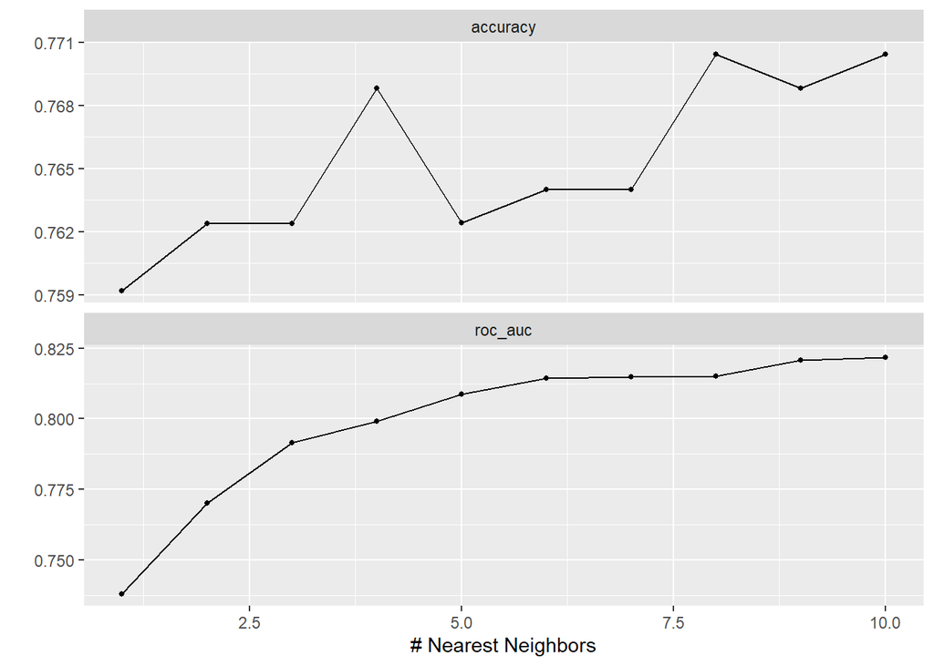

```r
autoplot(knn_fit_titan)
```

```r
#see how the logistic model did
subset(collect_metrics(log_fit_titan), .metric=="roc_auc")
```

```
## # A tibble: 1 × 6
##   .metric .estimator  mean     n std_err .config
##   <chr>   <chr>      <dbl> <int>   <dbl> <chr>
## 1 roc_auc binary     0.852     5  0.0153 Preprocessor1_Model1
```

```r
#see how the ENLog model did
ENLog_model_titan <- subset(collect_metrics(ENLog_fit_titan), .metric=="roc_auc")
ENLog_model_titan[order(ENLog_model_titan$mean, decreasing=TRUE),]
```

```
## # A tibble: 100 × 8
##          penalty mixture .metric .estimator  mean     n std_err .config
##            <dbl>   <dbl> <chr>   <chr>      <dbl> <int>   <dbl> <chr>
##  1 0.0000000001    1     roc_auc binary     0.852     5  0.0157 Preprocessor1_M…
##  2 0.00000000129   1     roc_auc binary     0.852     5  0.0157 Preprocessor1_M…
##  3 0.0000000167    1     roc_auc binary     0.852     5  0.0157 Preprocessor1_M…
##  4 0.000000215     1     roc_auc binary     0.852     5  0.0157 Preprocessor1_M…
##  5 0.00000278      1     roc_auc binary     0.852     5  0.0157 Preprocessor1_M…
##  6 0.0000359       1     roc_auc binary     0.852     5  0.0157 Preprocessor1_M…
##  7 0.000464        0.333 roc_auc binary     0.852     5  0.0158 Preprocessor1_M…
##  8 0.000464        0.444 roc_auc binary     0.852     5  0.0158 Preprocessor1_M…
##  9 0.000464        0.556 roc_auc binary     0.852     5  0.0158 Preprocessor1_M…
## 10 0.0000000001    0.667 roc_auc binary     0.852     5  0.0156 Preprocessor1_M…
## # … with 90 more rows
```

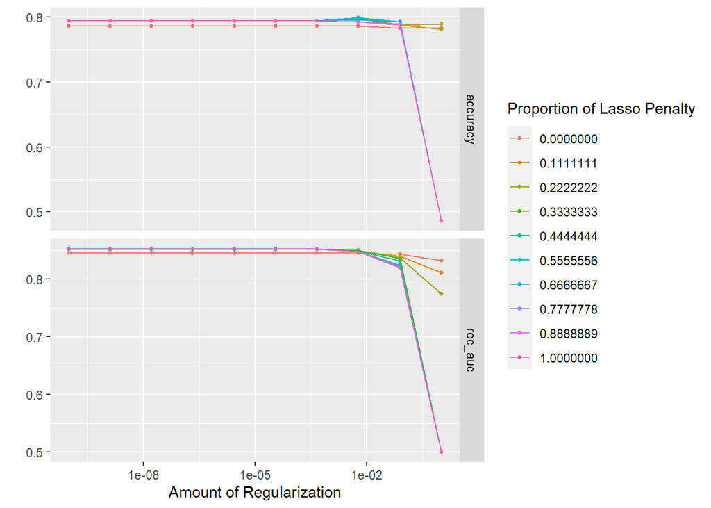

```r
autoplot(ENLog_fit_titan)
```

The model that performed the best was the logistic regression. This model has the highest ROC AUC and is also the simplist, which means less bias. Thus, I have concluded that the logistic regression is the best model.

### Question 12

```r
#fit the entire training set to the logistic model
final_fit_titan <- fit(log_work_titan, titanic_train)

#find roc auc
augment(final_fit_titan, new_data=titanic_train) %>%
  roc_auc(truth=survived, estimate=.pred_No)
```

```
## # A tibble: 1 × 3
##   .metric .estimator .estimate
##   <chr>   <chr>          <dbl>
## 1 roc_auc binary         0.865
```